# TSA HW09

R10A21126

WANGYIFAN

Simulate three random variables with length 1024, following standard Normal, $t$ -distribution (df = 10), and exponential distribution (rate = 1.6), respectively.

(a) Perform FFT (Fast Fourier Transform) over the three random variables and plot the amplitudes.

(b) Perform STFT (Short-Time Fourier Transform) over the three random variables and plot the time-frequency contours.

(c) What do you observe in (a) and (b)?

```r
# install.packages('e1071') # for stft
library('e1071')
```

```r
length = 1024
```

Standard Normal

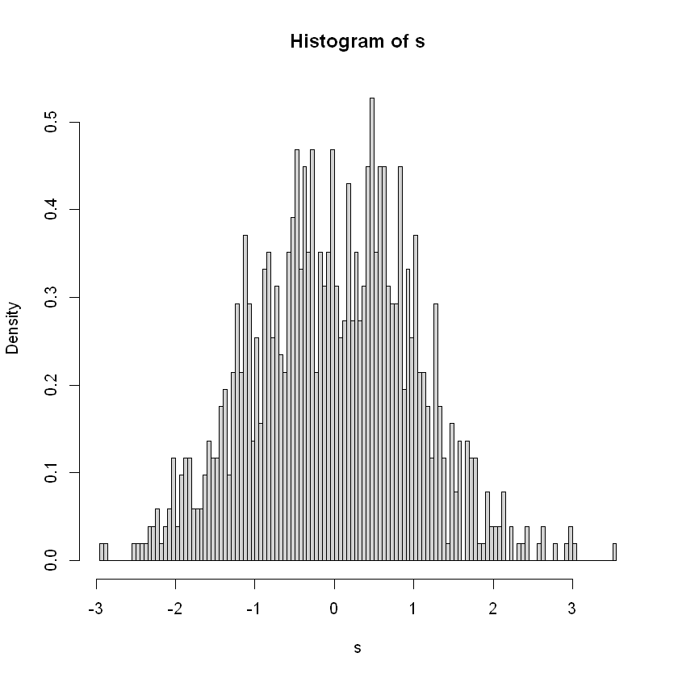

```r
s = rnorm(n= length, mean = 0, sd = 1)
hist(s,freq = FALSE,breaks = 100)
```

### FFT

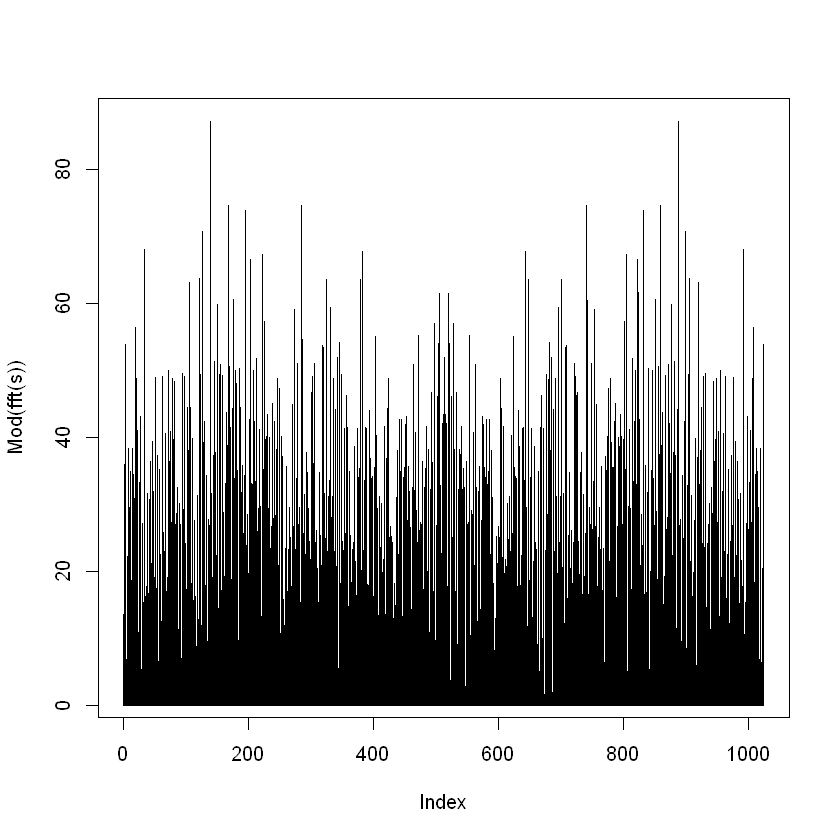

```r
plot(Mod(fft(s)),type = "h")
```

[scaling](https://rstudio-pubs-static.s3.amazonaws.com/28854_e3e2ddcee7294296b8629947cdf0d87f.html)

```r
plot.frequency.spectrum <- function(X.k, xlimits=c(0,length(X.k))) {
  plot.data  <- cbind(0:(length(X.k)-1), Mod(X.k))

  # TODO: why this scaling is necessary?
  plot.data[2:length(X.k),2] <- 2*plot.data[2:length(X.k),2]

  plot(plot.data, t="h", lwd=1, main="",
       xlab="Frequency (Hz)", ylab="Strength",
       xlim=xlimits, ylim=c(0,max(Mod(plot.data[,2]))))
}
```

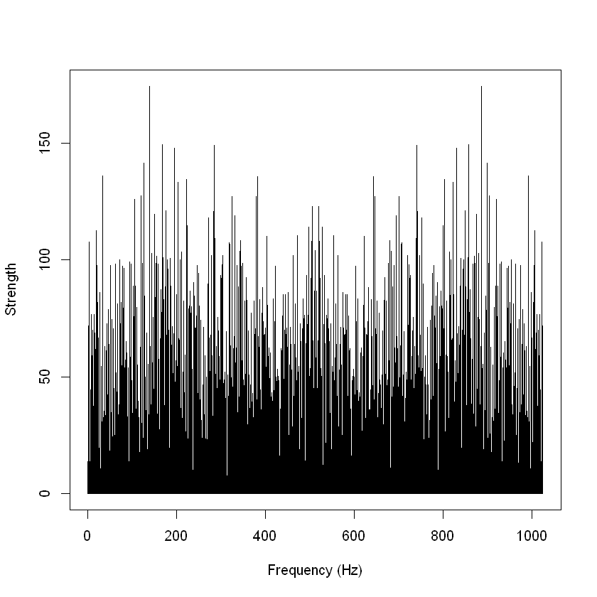

```r
plot.frequency.spectrum(fft(s))
```

### STFT

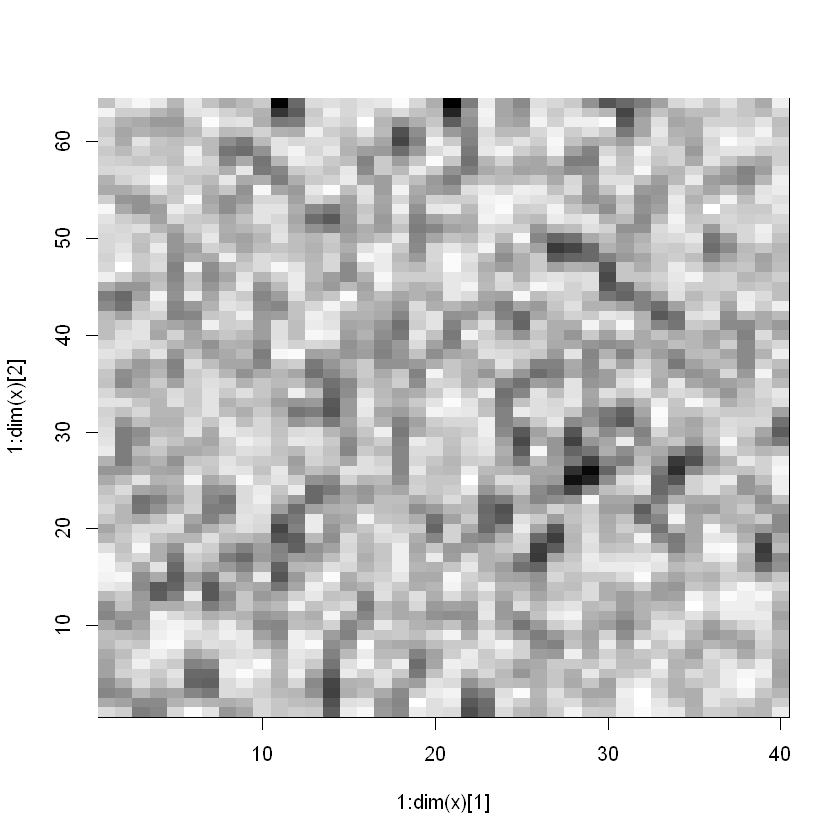

```r
plot(stft(s))
```

$t$ -distribution (df = 10)

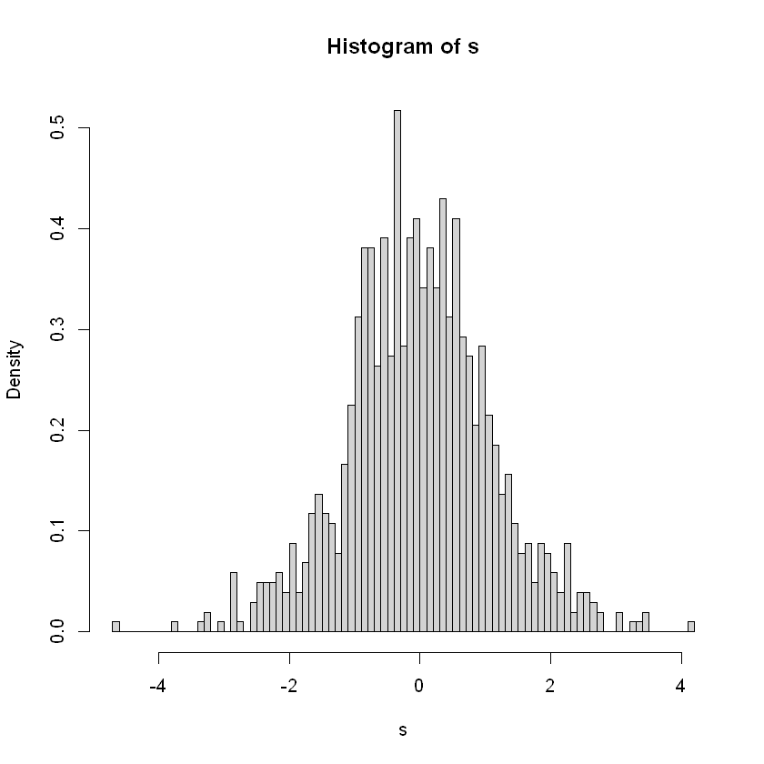

```r
s = rt(n=length, df = 10)
hist(s,freq = FALSE,breaks = 100)
```

### FFT

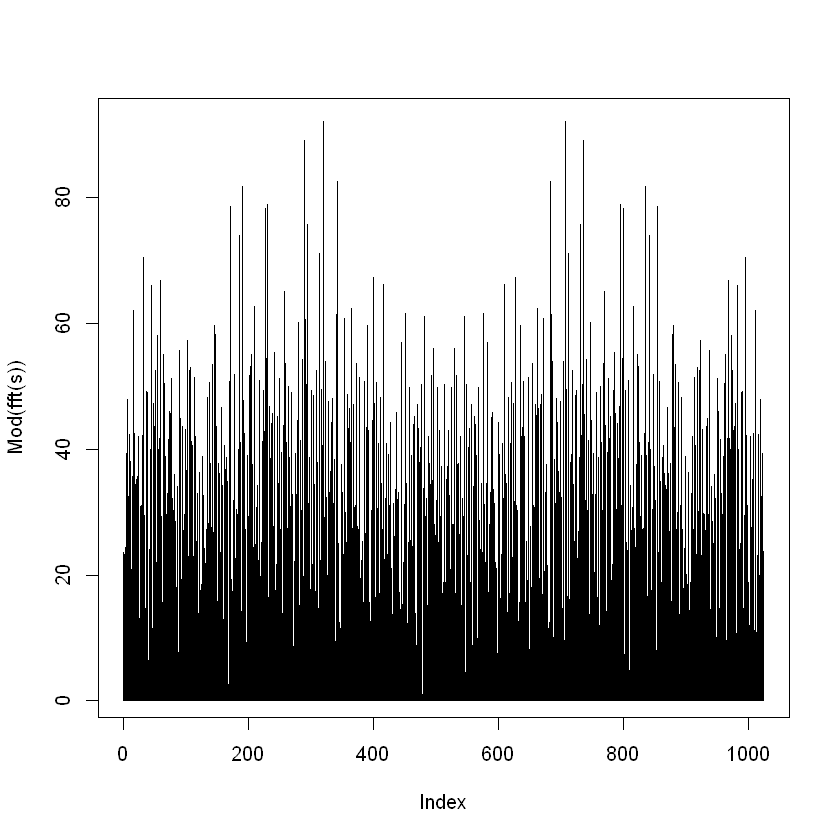

```r
plot(Mod(fft(s)),type = "h")
```

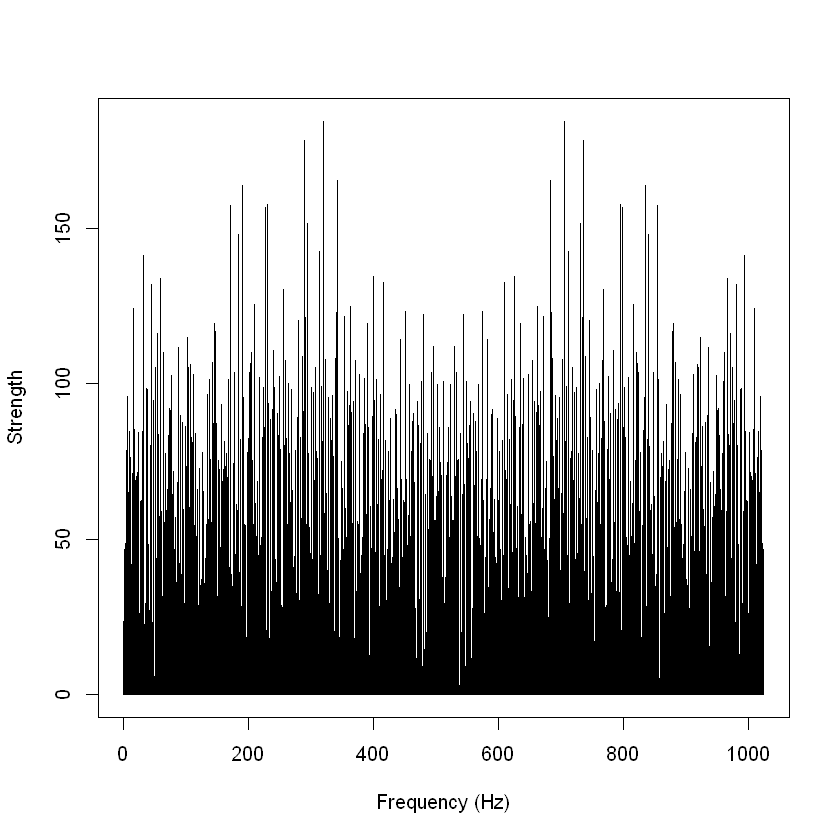

```r
plot.frequency.spectrum(fft(s))
```

### STFT

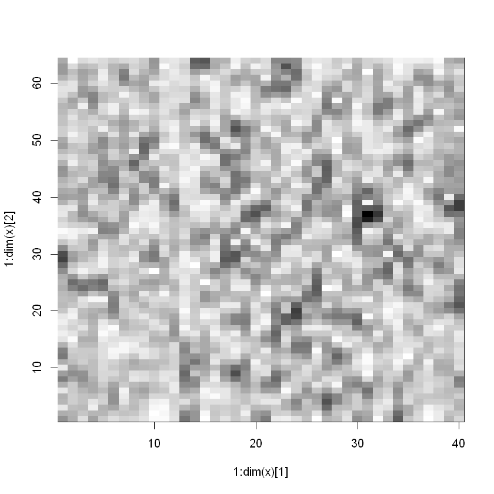

```r
plot(stft(s))
```

exponential distribution (rate = 1.6)

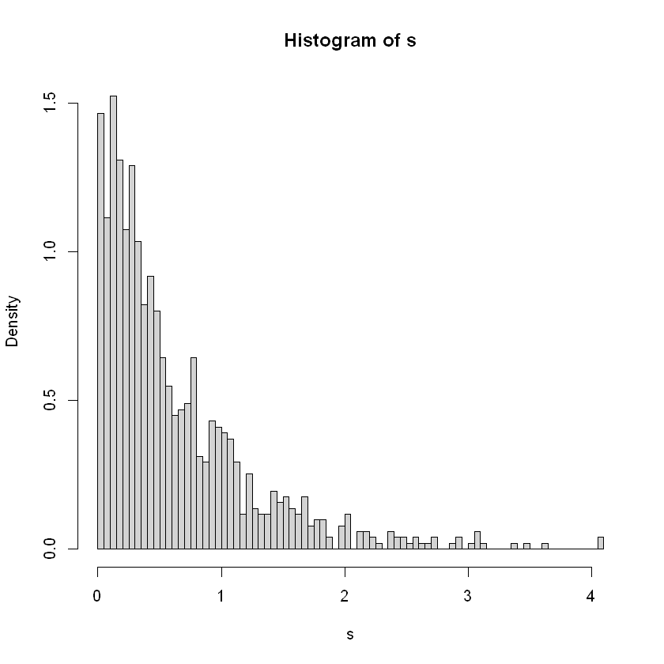

```r
s = rexp(n = length, rate = 1.6)
hist(s,freq = FALSE,breaks = 100)
```

### FFT

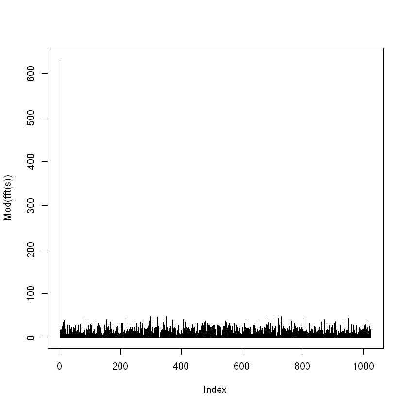

```r
plot(Mod(fft(s)),type = "h")
```

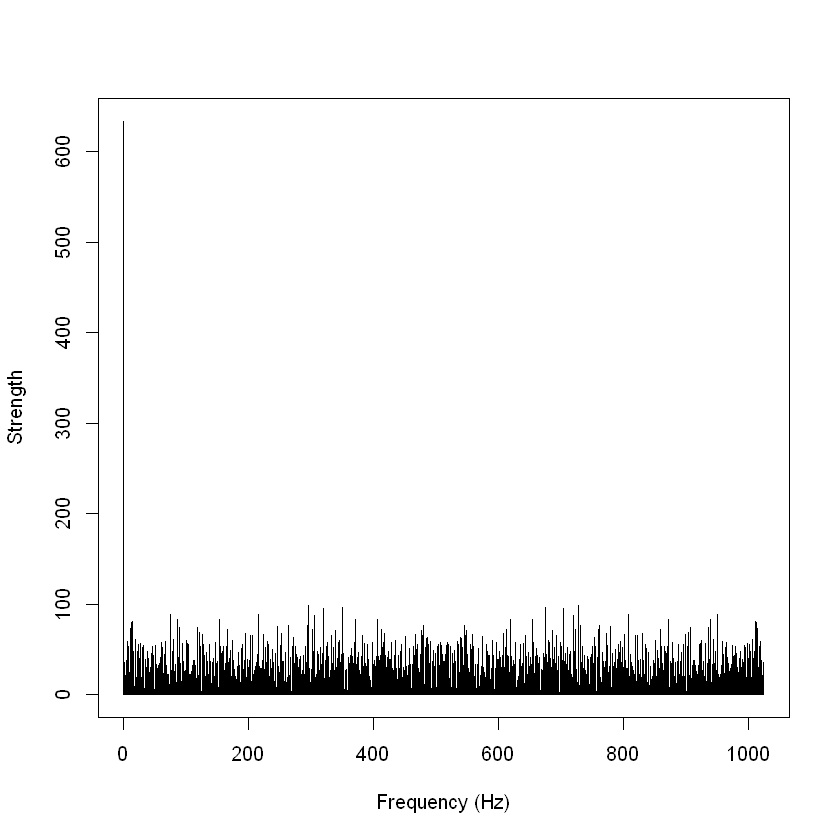

```r
plot.frequency.spectrum(fft(s))
```

The first value of the FFT coefficient is large, implying that the sequence has a strong overall trend.

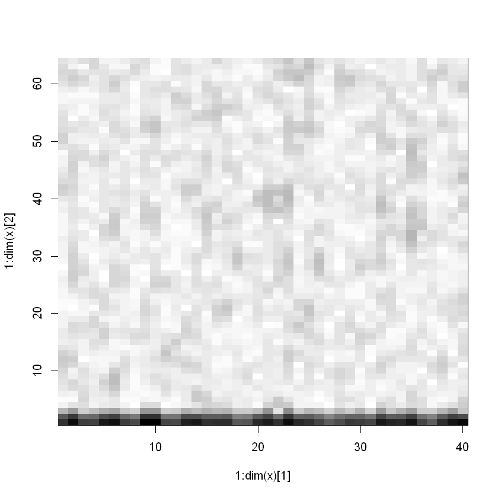

```r
plot(stft(s))
```

The frequency components for the sequence is low frequency.

##### To read and analyze an FFT plot, we need to understand the following elements of the plot:

X-axis: The x-axis of an FFT plot typically represents the frequency of the FFT coefficients. The frequency range depends on the length of the time series and the sampling frequency. For example, if the time series has length $N$ and the sampling frequency is $f_s$, the frequencies on the x-axis will range from 0 to $f_s / 2$.

Y-axis: The y-axis of an FFT plot typically represents the amplitude of the FFT coefficients. The amplitude of the FFT coefficients indicates the strength of the corresponding frequency component in the time series.

Data points: The data points on an FFT plot show the amplitudes of the FFT coefficients for each frequency. These data points can be connected by a line to create a line plot of the amplitudes.

To analyze the FFT plot, we can look for patterns in the amplitudes of the FFT coefficients. For example, we can look for peaks in the amplitudes, which indicate the dominant frequency components in the time series. We can also look for periodic patterns in the amplitudes, which indicate the presence of periodic signals in the time series. Additionally, we can compare the amplitudes of the FFT coefficients at different frequencies to assess the overall distribution of the frequency components in the time series.

- The first value of the FFT (Fast Fourier Transform) represents the coefficient for the frequency component with frequency 0. This coefficient is often called the "DC component" of the time series, and it represents the average value of the time series. The amplitude of the first FFT coefficient can be useful for assessing the overall trend of the time series. For example, if the amplitude of the first FFT coefficient is large, it indicates that the time series has a strong overall trend. However, if the amplitude of the first FFT coefficient is small, it indicates that the time series does not have a strong overall trend.
- To understand the trend of the FFT (Fast Fourier Transform) coefficients, we can look at the amplitudes of the FFT coefficients for different frequencies. The amplitudes of the FFT coefficients indicate the strength of the corresponding frequency components in the time series. Therefore, the overall trend of the FFT coefficients can be assessed by looking for patterns in the amplitudes of the FFT coefficients.
- For example, if the amplitudes of the FFT coefficients decrease as the frequency increases, it indicates that the time series has a strong overall trend (i.e., it is mostly made up of low-frequency components). On the other hand, if the amplitudes of the FFT coefficients are relatively constant across different frequencies, it indicates that the time series does not have a strong overall trend (i.e., it is made up of a mix of different frequency components).
- Additionally, we can look at the amplitudes of the FFT coefficients for specific frequency ranges to assess the trend in different parts of the time series. For example, if the amplitudes of the FFT coefficients are high in the low-frequency range and low in the high-frequency range, it indicates that the time series has a strong trend in the low-frequency range and a weak trend in the high-frequency range. This information can be useful for understanding the characteristics of the time series and for modeling the time series.

##### To read and analyze an STFT plot, we need to understand the following elements of the plot:

X-axis: The x-axis of an STFT plot typically represents the time points of the time series. The time range depends on the length of the time series and the sampling frequency. For example, if the time series has length $N$ and the sampling frequency is $f_s$, the time points on the x-axis will range from 0 to $N / f_s$.

Y-axis: The y-axis of an STFT plot typically represents the frequency of the FFT coefficients. The frequency range depends on the length of the time series and the sampling frequency. For example, if the time series has length $N$ and the sampling frequency is $f_s$, the frequencies on the y-axis will range from 0 to $f_s / 2$.

Colors: The colors in an STFT plot show the strength of the frequency components at each time point. Typically, stronger frequency components are indicated by darker colors, and weaker frequency components are indicated by lighter colors.

To analyze the STFT plot, we can look for patterns in the time-frequency contours. For example, we can look for peaks in the contours, which indicate the dominant frequency components at each time point. We can also look for changes in the contours over time, which indicate how the frequency components of the time series change over time. Additionally, we can compare the contours at different time points to assess the overall distribution of the frequency components in the time series.

##### After performing the Fast Fourier Transform (FFT) and the Short-Time Fourier Transform (STFT) on the time series, we should observe the following:

In the FFT plot, we should see a line plot of the amplitudes of the FFT coefficients of the time series. This plot shows the frequency components of the time series, and the amplitudes of the FFT coefficients indicate the strength of each frequency component in the time series.

In the STFT plot, we should see a spectrogram showing the time-frequency contours of the time series. This plot shows how the frequency components of the time series change over time. The time-frequency contours show the strength of the frequency components at each time point, and the colors in the plot indicate the strength of the frequency components.

Overall, the FFT and STFT plots provide useful information about the frequency components of the time series, which can be useful for analyzing and modeling the time series.

## Simulate a seasonal time series following the model SARIMA $(2,1,0) \times (0,1,1)_{12}$

(a) Perform FFT (Fast Fourier Transform) over the time series and plot the amplitudes.

(b) Perform STFT (Short-Time Fourier Transform) over the time series and plot the time-frequency contours.

(c) What do you observe in (a) and (b)?

```r
# library('TSA')
```

### Simulate seasonal time series SRAIMA $(2,1,0) \times (0,1,1)_{12}$

```r
library(forecast)
# Simulate a seasonal time series using the function from the forecast package
model <- Arima(ts(rnorm(100),freq=12), order=c(2,1,0), seasonal=c(0,1,1),
                fixed=c(phi=c(-0.1,0.5), theta=c(-0.5)))
s <- simulate(model, nsim=1024)
fit <- Arima(s, order=c(2,1,0), seasonal=c(0,1,1))
```

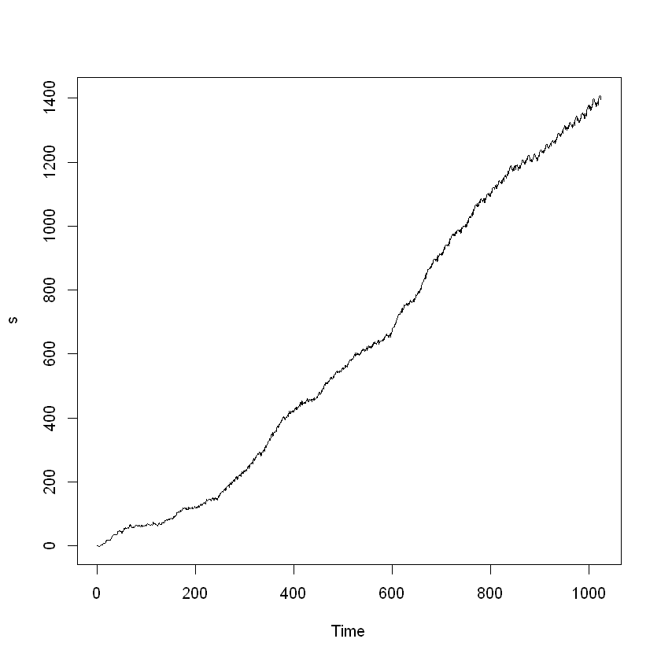

```r
plot(s)
```

```r
s = ts(s)
```

```r
fit
```

```
Series: s
ARIMA(2,1,0)(0,1,1)[12]

Coefficients:
          ar1     ar2     sma1
      -0.0924  0.4798  -0.5446
s.e.   0.0277  0.0276   0.0287

sigma^2 = 3.142:  log likelihood = -2014.16
AIC=4036.32   AICc=4036.36   BIC=4056
```

```r
library('lmtest')
coeftest(fit)
```

```
z test of coefficients:

      Estimate Std. Error  z value  Pr(>|z|)
ar1  -0.092417   0.027749  -3.3305  0.000867 ***
ar2   0.479831   0.027620  17.3729 < 2.2e-16 ***
sma1 -0.544600   0.028748 -18.9441 < 2.2e-16 ***
---
Signif. codes:  0 '***' 0.001 '**' 0.01 '*' 0.05 '.' 0.1 ' ' 1
```

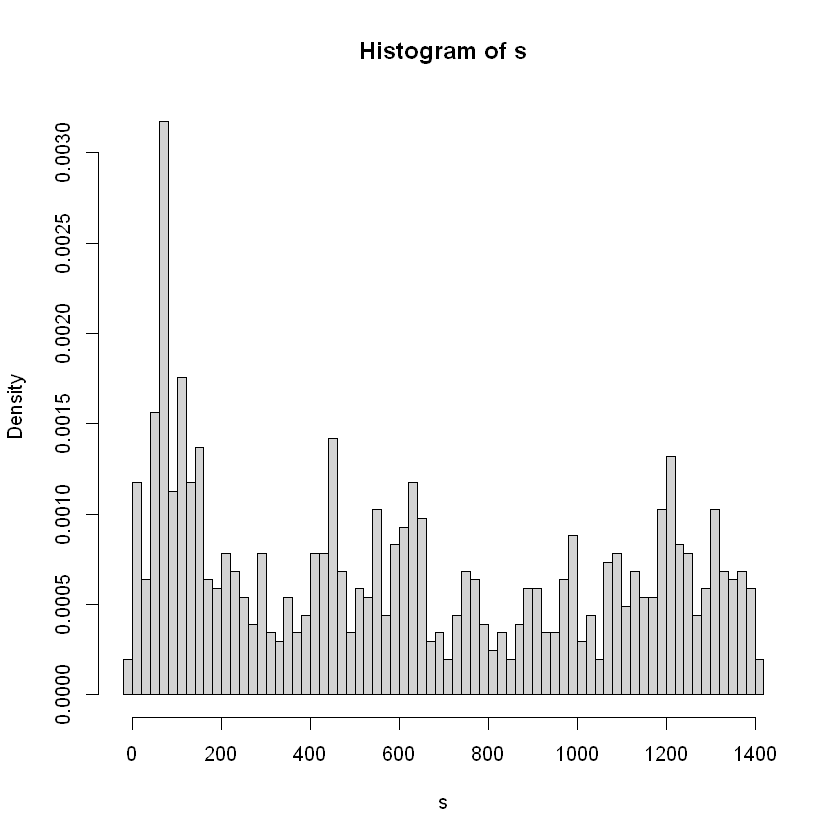

```r
hist(s,freq=FALSE,breaks=100)
```

### FFT

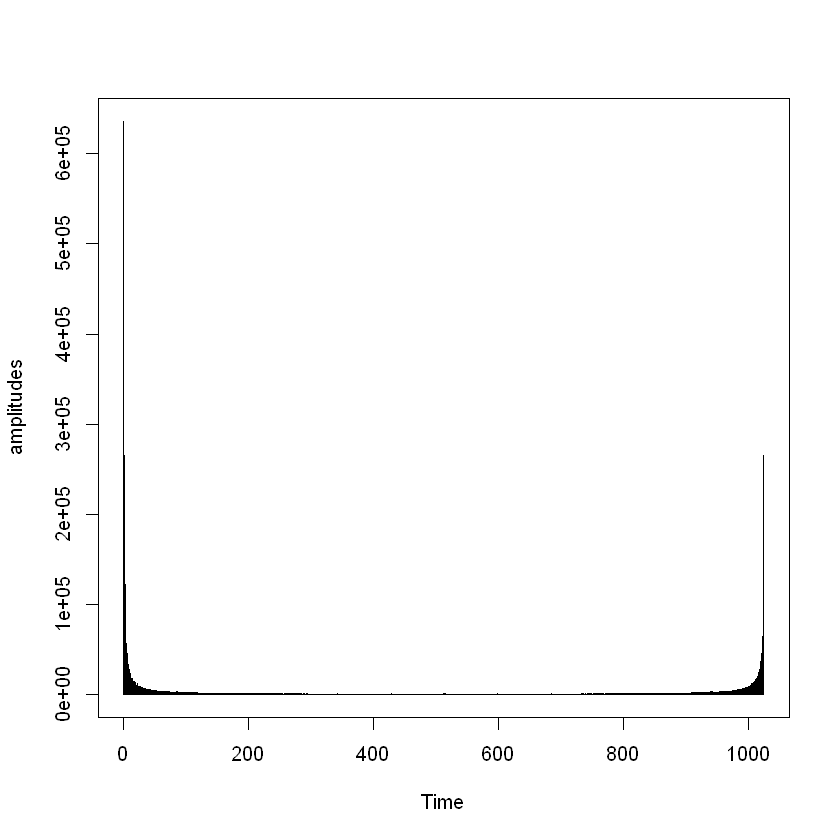

```r
# Extract the amplitudes from the FFT result
amplitudes <- abs(fft(s))

# Plot the amplitudes
plot(amplitudes, type = "h")
```

The first value of the FFT coefficient is large, implying that the sequence has a strong overall trend.

### STFT

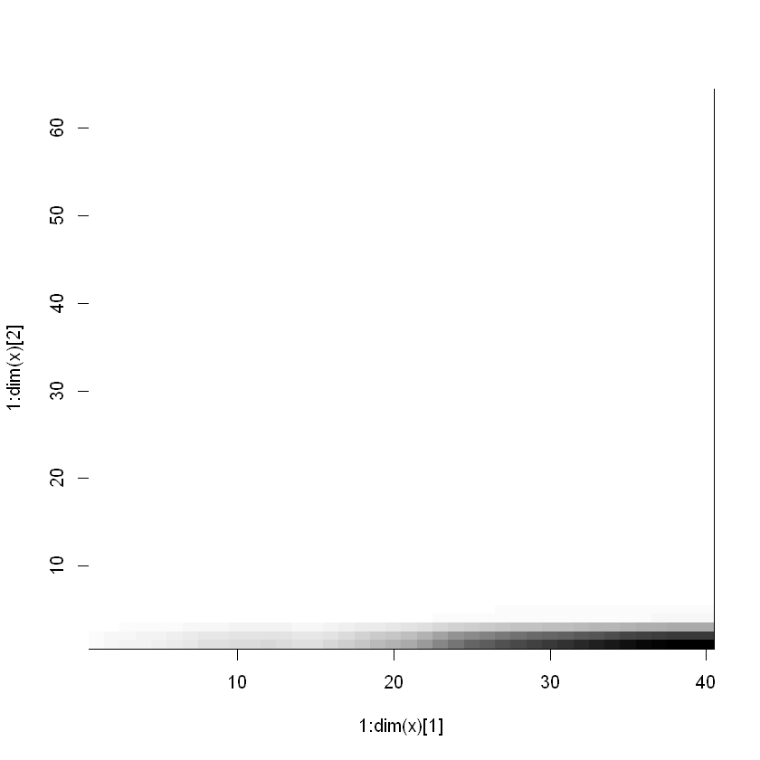

```r
plot(stft(s))
```

The frequency components for the sequence is low frequency.

## Method 2

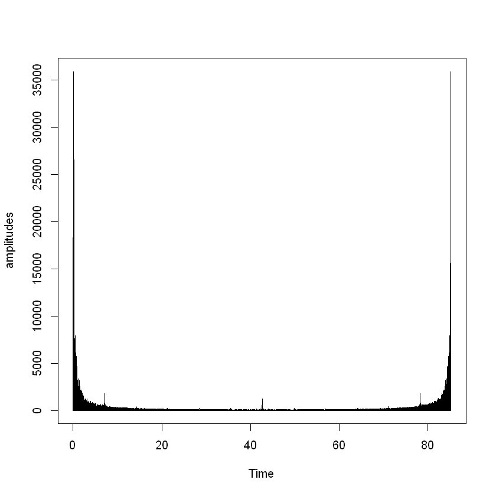

```r
# Load the astsa package
library(astsa)

# Set the seed for reproducibility
set.seed(123)

# Simulate a seasonal time series using the sarima.sim() function from the astsa package

x <- sarima.sim(ar = c(-0.1,0.5),d=1, D=1, sma=-.6, S=12, n=1024)

# Perform the FFT on the time series
fft_result <- fft(x)

# Extract the amplitudes from the FFT result
amplitudes <- abs(fft_result)

# Plot the amplitudes
plot(amplitudes, type = "h")
```

The first value of the FFT coefficient is large, implying that the sequence has a strong overall trend.

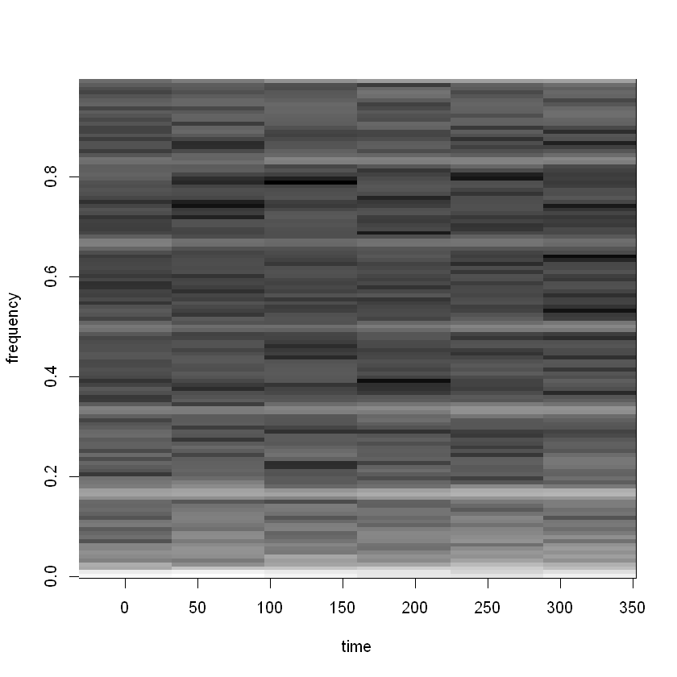

```r
library(signal)

# compute STFT and plot time-frequency contours
specgram(x)
```